# Analysis for Experiment 2

KN

2025-02-25

For output from ibex farm

# 1 About

- SPR conducted at Lancers ibex, May 8, 2018
- 116 participants
- Target items: 24
- Filler items: 48

Conditions:  
Ds. Durative × Simplex  
Dr. Durative x Reduplicated  
Cs. Non-durative x Simplex  
Cr. Non-durative x Reduplicated

[[“Ds”,1], “DashedSentenceNoSpace”,  
{s: “生徒が しばらく 黒板を ちらっと 見たので 先生が カンニングを 疑った。”},  
“Question”, {q: “生徒は黒板をしばらく見た。”, hasCorrect:0}], [[“Dr”,1], “DashedSentenceNoSpace”,  
{s: “生徒が しばらく 黒板を ちらちら 見たので 先生が カンニングを 疑った。”}, “Question”,  
{q: “生徒は黒板をしばらく見た。”, hasCorrect:0}], [[“Cs”,1], “DashedSentenceNoSpace”,  
{s: “生徒が その時 黒板を ちらっと 見たので 先生が カンニングを 疑った。”},  
“Question”, {q: “生徒は黒板をしばらく見た。”, hasCorrect:1}], [[“Cr”,1], “DashedSentenceNoSpace”,  
{s: “生徒が その時 黒板を ちらちら 見たので 先生が カンニングを 疑った。”},  
“Question”, {q: “生徒は黒板をしばらく見た。”, hasCorrect:1}],

# 2 Preamble

## 2.1 Load libraries

```r
#library(lme4)
library(lmerTest)
library(plyr)
library(dplyr)
```

```r
library(ggplot2)
library(reshape)
library(gdata)
library(MASS)
```

## 2.2 Declare the expt name that is relevant.

```r
ex<-"e"

# critical region
criticalregion<-4

# how far from the critical region do you want the plot to cover?
crplus<-3

# plot legend（凡例）のならび順はデフォルトではアルファベット順
# 逆順にしたい場合はここを1にする
revorderA <- 1  # ab vs cd
revorderB <- 1  # ac vs bd
```

## 2.3 Trimming criteria

```r
# Trim bad subjects: data<-subset(data,SubjCA>=trimSubjCA)
# No trimming: trimSubjCA <- 0
trimSubjCA <- 200/3
# Trim bad subjects: data<-subset(data,SubjExptCA>=trimSubjExptCA)
# No trimming: trimSubjExptCA <- 0
trimSubjExptCA <- 0

# Trim slow subjects: data<-subset(data,SubjRTZS<trimSubjRTZS)
# (Virtually) No trimming: trimSubjRTZS <- 99
trimSubjRTZS <- 3

# Trim slow subjects: data<-subset(data,SubjRTmean<trimSubjRTmean)
# (Virtually) No trimming: trimSubjRTZS <- 10000
trimSubjRTmean <- 10000


# Trim incorrectly answered trials?  if( trimincorrect == 1 ){ rt_data<-subset(rt_data,correct==100) }
# No trimming: trimincorrect <- 0
trimincorrect <- 1

# Trim extreme RTs rt_data<-subset(rt_data_notrim,rt>=RTlowerbound & rt<=RTupperbound)
# (Virtually) No trimming: upperboundRT <- 100000
upperboundRT <- 10000
# No trimming: upperboundRT <- 100000
# No trimming: lowerboundRT <- 0
lowerboundRT <- 150

# Then RxC z-scores will be computed
# Trim based on zs in each condition x region cell d<-subset(rt_data,RxCzs<trimRxCzs)
# (Virtually) No trimming: trimRxCzs <- 99
trimRxCzs <- 3

# RT transformation
tf <- "none"  # No transformation
#tf <- "log"   # Log transformation
#tf <- "log10"  # Log10 transformation
#tf <- "negreciprocal" # Negative reciprocal *1000

# Want to center the spillover? (Usually yes)
spillovercentering <- 1

# Want to z-transform the spillover?
spilloverztransform <- 1
```

## 2.4 Load data:

```r
alldata<-read.csv("alldata.csv",header=T)
alldata<-alldata[,-1]
alldata$item<-as.numeric(alldata$item)
itemdata<-read.csv("itemdata.csv")
itemdata<-itemdata[,-1]
# 標準化（z値化）
# 注：scale()[,1]としているのは，scale()は行列を返すので，「列1だけ出力おねがい」という意味
itemdata$Itemvalue<-scale(itemdata$Itemvalue, center = T, scale = T)[,1]
alldata <- merge(alldata,itemdata,all=T);
```

## 2.5 Isolate the data from the relevant experiment

```r
data<-subset(alldata,expt==ex)
unique(data$expt)
```

```
## [1] "e"
```

# 3 Subj exclusion

## 3.1 before trimming

Subject number before trimming

```r
unique(data$subj)
```

```
##   [1]  95  43  39  65  91  62  75  69  67  68  45  74  20  66  92  22  40  97
##  [19] 102  98 100  93  89  77  71  47  44  18  73  72  99  90  48 101  12  94
##  [37]  42  14  46  16  88  37  38  10  51  96  63  36  76  41  24  70 106 115
##  [55]   8  19 103  35  17  26  34  61  64 116 112  15   6 104 105  28  53   4
##  [73] 114  33  31  13 109  59  60  86  57  11  49  78  80 108  55   2  32  58
##  [91] 113  87   9  82  30 110 111  85   7  25  54  56   5  23  52 107  81  29
## [109]  83  84   3  21  50  79  27   1
```

```r
length(unique(data$subj))
```

```
## [1] 116
```

## 3.2 trim by CA

```r
data<-subset(data,SubjCA>=trimSubjCA)
unique(data$subj)
```

```
##   [1]  95  43  39  65  91  62  75  69  67  68  45  74  20  66  92  22  40  97
##  [19] 102  98 100  93  89  77  71  47  44  18  73  72  99  90  48  12  94  42
##  [37]  14  46  16  88  37  38  10  51  96  63  36  76  41  70 106   8  19 103
##  [55]  35  26  34  61  64 116 112  15   6 104 105  28  53   4 114  33  31  13
##  [73] 109  59  60  86  57  11  49  78  80 108  55   2  32  58 113  87   9  82
##  [91]  30 111  85   7  25  54  56   5  23  52 107  81  29  83  84   3  21  50
## [109]  79  27   1
```

```r
length(unique(data$subj))
```

```
## [1] 111
```

```r
data<-subset(data,SubjExptCA>=trimSubjExptCA)
unique(data$subj)
```

```
##   [1]  95  43  39  65  91  62  75  69  67  68  45  74  20  66  92  22  40  97
##  [19] 102  98 100  93  89  77  71  47  44  18  73  72  99  90  48  12  94  42
##  [37]  14  46  16  88  37  38  10  51  96  63  36  76  41  70 106   8  19 103
##  [55]  35  26  34  61  64 116 112  15   6 104 105  28  53   4 114  33  31  13
##  [73] 109  59  60  86  57  11  49  78  80 108  55   2  32  58 113  87   9  82
##  [91]  30 111  85   7  25  54  56   5  23  52 107  81  29  83  84   3  21  50
## [109]  79  27   1
```

```r
length(unique(data$subj))
```

```
## [1] 111
```

## 3.3 comprehension accuracy for each condition after the subject trimming

```r
check<-subset(data,region==1)
ddply(check, .(cond), summarize, mean=mean(correct))
```

```
##   cond     mean
## 1   Cr 76.12613
## 2   Cs 84.38438
## 3   Dr 87.08709
## 4   Ds 89.93994
```

```r
check$correct<-check$correct/100


check$adv<-ifelse(check$cond%in%c("Dr","Ds"),1,-1) #Dur vs. nondur
check$ideo<-ifelse(check$cond%in%c("Ds","Cs"),1,-1) #Simplex vs. Redup


checkglm<-glm(formula = correct ~ adv*ideo, data = check, family = binomial)
summary(checkglm)
```

```
##
## Call:
## glm(formula = correct ~ adv * ideo, family = binomial, data = check)
##
## Coefficients:
##             Estimate Std. Error z value Pr(>|z|)
## (Intercept)  1.73649    0.05568  31.188  < 2e-16 ***
## adv          0.31313    0.05568   5.624 1.87e-08 ***
## ideo         0.20235    0.05568   3.634 0.000279 ***
## adv:ideo    -0.06140    0.05568  -1.103 0.270096
## ---
## Signif. codes:  0 '***' 0.001 '**' 0.01 '*' 0.05 '.' 0.1 ' ' 1
##
## (Dispersion parameter for binomial family taken to be 1)
##
##     Null deviance: 2308.3  on 2663  degrees of freedom
## Residual deviance: 2256.4  on 2660  degrees of freedom
## AIC: 2264.4
##
## Number of Fisher Scoring iterations: 4
```

## 3.4 mean accuracy rate for each condition

```r
cddata<-subset(data,cond =="Cs",select=c(subj, correct, region))
cddata<-subset(cddata, region=="1")
#cddata
```

```r
numsubj<-length(cddata$subj)
sumcorrect<-sum(cddata$correct)
sumcorrect/numsubj
```

```
## [1] 84.38438
```

```r
cddata<-subset(data,cond =="Cr",select=c(subj, correct, region))
cddata<-subset(cddata, region=="1")
#cddata
```

```r
numsubj<-length(cddata$subj)
sumcorrect<-sum(cddata$correct)
sumcorrect/numsubj
```

```
## [1] 76.12613
```

```r
cddata<-subset(data,cond =="Ds",select=c(subj, correct, region))
cddata<-subset(cddata, region=="1")
#cddata
```

```r
numsubj<-length(cddata$subj)
sumcorrect<-sum(cddata$correct)
sumcorrect/numsubj
```

```
## [1] 89.93994
```

```r
cddata<-subset(data,cond =="Dr",select=c(subj, correct, region))
cddata<-subset(cddata, region=="1")
cddata
```

[output not shown]

[output cut: 652 more lines]

```r
numsubj<-length(cddata$subj)
sumcorrect<-sum(cddata$correct)
sumcorrect/numsubj
```

```
## [1] 87.08709
```

## 3.5 trim by RTZS

```r
data<-subset(data,SubjRTZS<=trimSubjRTZS)
unique(data$subj)
```

```
##   [1]  95  43  39  65  91  62  75  69  67  68  45  74  20  66  92  22  40  97
##  [19] 102  98 100  93  89  77  71  47  44  18  72  99  90  48  12  94  42  14
##  [37]  46  16  88  37  38  10  51  96  63  36  76  41  70 106   8  19 103  35
##  [55]  26  34  61  64 116 112  15   6 104 105  28  53   4 114  33  31  13 109
##  [73]  59  60  86  57  11  49  78  80 108  55   2  32  58 113  87   9  82  30
##  [91] 111  85   7  25  54  56   5  23  52 107  81  29  83  84   3  21  50  79
## [109]  27   1
```

```r
length(unique(data$subj))
```

```
## [1] 110
```

## 3.6 trim by RTmean

```r
data<-subset(data,SubjRTmean<=trimSubjRTmean)
unique(data$subj)
```

```
##   [1]  95  43  39  65  91  62  75  69  67  68  45  74  20  66  92  22  40  97
##  [19] 102  98 100  93  89  77  71  47  44  18  72  99  90  48  12  94  42  14
##  [37]  46  16  88  37  38  10  51  96  63  36  76  41  70 106   8  19 103  35
##  [55]  26  34  61  64 116 112  15   6 104 105  28  53   4 114  33  31  13 109
##  [73]  59  60  86  57  11  49  78  80 108  55   2  32  58 113  87   9  82  30
##  [91] 111  85   7  25  54  56   5  23  52 107  81  29  83  84   3  21  50  79
## [109]  27   1
```

```r
length(unique(data$subj))
```

```
## [1] 110
```

# 4 Reading time summary

```r
rt_data<-data
```

Make sure factors are treated as factors

```r
rt_data$subj<-factor(rt_data$subj)
rt_data$expt<-factor(rt_data$expt)
rt_data$item<-factor(rt_data$item)
rt_data$cond<-factor(rt_data$cond)
rt_data$word<-factor(rt_data$word)
```

## 4.1 Correctly answered trials only? (trimincorrect)

Note: if you do this trimming at this point, it precedes the z-score computation.

```r
before <- length(data$rt)
before
```

```
## [1] 21120
```

```r
rt_data<-subset(data,correct==100)
```

```r
after <- length(rt_data$rt)
after
```

```
## [1] 17808
```

```r
(before-after)*100/before
```

```
## [1] 15.68182
```

## 4.2 RT trimming based on z-scores

```r
subset(rt_data,rt<200 & region==1,c("expt","cond","region","rt"))
```

```
##       expt cond region  rt
## 3902     e   Cs      1 148
## 9368     e   Ds      1 182
## 13154    e   Ds      1 199
## 15780    e   Cr      1 133
```

```r
subset(rt_data,rt<200 & region==2,c("expt","cond","region","rt"))
```

```
##       expt cond region  rt
## 9866     e   Dr      2 198
## 13494    e   Ds      2 184
## 19966    e   Ds      2 190
## 20764    e   Cs      2 136
## 21444    e   Dr      2 199
```

```r
subset(rt_data,rt<200 & region==3,c("expt","cond","region","rt"))
```

```
##       expt cond region  rt
## 6168     e   Dr      3 191
## 7204     e   Cs      3 185
## 7941     e   Cr      3 189
## 10152    e   Dr      3 196
## 16433    e   Cr      3 190
## 21526    e   Dr      3 194
```

```r
subset(rt_data,rt<200 & region==4,c("expt","cond","region","rt"))
```

```
##       expt cond region  rt
## 5069     e   Ds      4 191
## 9867     e   Dr      4 190
## 10297    e   Dr      4 190
## 14580    e   Cs      4 169
## 19907    e   Cr      4 151
```

```r
subset(rt_data,rt<200 & region==5,c("expt","cond","region","rt"))
```

```
##       expt cond region  rt
## 5070     e   Ds      5 195
## 7582     e   Cs      5 193
## 9868     e   Dr      5 198
## 13482    e   Ds      5 191
```

```r
subset(rt_data,rt<200 & region==6,c("expt","cond","region","rt"))
```

```
## [1] expt   cond   region rt
## <0 rows> (or 0-length row.names)
```

```r
subset(rt_data,rt>3000 & region==1,c("expt","cond","region","rt"))
```

```
##       expt cond region   rt
## 1098     e   Cr      1 3861
## 3129     e   Cr      1 3730
## 4646     e   Cs      1 3216
## 7539     e   Dr      1 3416
## 7690     e   Cr      1 4916
## 11941    e   Cs      1 3138
## 12177    e   Ds      1 3024
## 16919    e   Dr      1 3672
## 19508    e   Ds      1 3264
## 20417    e   Cs      1 4874
## 20526    e   Cr      1 3231
## 21423    e   Cs      1 3964
```

```r
subset(rt_data,rt>3000 & region==2,c("expt","cond","region","rt"))
```

```
##       expt cond region    rt
## 3659     e   Ds      2  5129
## 6718     e   Dr      2  3699
## 17208    e   Cs      2  6440
## 20554    e   Ds      2 25569
```

```r
subset(rt_data,rt>3000 & region==3,c("expt","cond","region","rt"))
```

```
##       expt cond region    rt
## 2085     e   Cr      3 13263
## 9388     e   Cr      3  3061
## 10560    e   Ds      3  8761
```

```r
subset(rt_data,rt>3000 & region==4,c("expt","cond","region","rt"))
```

```
##       expt cond region   rt
## 4225     e   Dr      4 3424
## 6513     e   Ds      4 4514
## 13068    e   Cs      4 5088
## 13613    e   Dr      4 4448
## 14528    e   Cr      4 3175
## 18106    e   Ds      4 6471
## 18118    e   Cr      4 3209
```

```r
subset(rt_data,rt>3000 & region==5,c("expt","cond","region","rt"))
```

```
##       expt cond region   rt
## 243      e   Ds      5 4391
## 1786     e   Ds      5 3414
## 2648     e   Cs      5 3464
## 2941     e   Ds      5 3378
## 3298     e   Ds      5 3014
## 3680     e   Cr      5 3999
## 4457     e   Ds      5 3687
## 6295     e   Cr      5 4111
## 9012     e   Dr      5 3722
## 9291     e   Ds      5 4204
## 10365    e   Ds      5 4394
## 11765    e   Dr      5 5824
## 12809    e   Dr      5 3464
## 12953    e   Dr      5 3344
## 13440    e   Cr      5 3396
## 14176    e   Ds      5 3562
## 14706    e   Ds      5 3496
## 16766    e   Cr      5 4685
## 18078    e   Cs      5 3535
## 18761    e   Dr      5 3008
```

```r
subset(rt_data,rt>3000 & region==6,c("expt","cond","region","rt"))
```

```
##       expt cond region   rt
## 15971    e   Cr      6 3062
```

```r
tapply(rt_data$rt, rt_data$region, mean)
```

```
##        1        2        3        4        5        6        7        8
## 725.5171 602.9879 609.8095 597.8634 668.6559 595.0710 552.6199 672.0364
```

```r
tapply(rt_data$rt, paste(rt_data$region, rt_data$cond), mean)
```

```
##     1 Cr     1 Cs     1 Dr     1 Ds     2 Cr     2 Cs     2 Dr     2 Ds
## 738.8942 734.1400 725.1374 706.4840 582.3014 602.2316 582.7443 640.8044
##     3 Cr     3 Cs     3 Dr     3 Ds     4 Cr     4 Cs     4 Dr     4 Ds
## 635.1018 598.0359 595.3930 613.4789 585.0639 596.1095 594.1235 613.9511
##     5 Cr     5 Cs     5 Dr     5 Ds     6 Cr     6 Cs     6 Dr     6 Ds
## 641.1657 642.5189 646.3757 738.0354 583.7425 589.9964 594.8348 609.6374
##     7 Cr     7 Cs     7 Dr     7 Ds     8 Cr     8 Cs     8 Dr     8 Ds
## 555.4212 544.7989 558.6678 551.7352 642.2375 685.4004 711.8991 646.0067
```

rt trimming

```r
rt_data_notrim <- rt_data

rt_data<-subset(rt_data_notrim,rt>=lowerboundRT & rt<=upperboundRT)
```

Generate z-scores for variable A using the scale() function scale(A, center = TRUE, scale = TRUE)

```r
myRT <- c()
newdataframe <- c()
for(i in unique(rt_data$region)){
  for(j in unique(rt_data$cond)){
    # abstract rt column in the region x cond cell
    myRT <- subset(rt_data, region==i & cond==j);
    # compute z-score; [,1]を付けるのはscale()が行列データを返すので列1だけ出力してという意味
    myRT$RxCzs <- scale(myRT$rt, center = T, scale = T)[,1];
    # 蓄積
    newdataframe<-rbind(newdataframe,myRT);
    }
};

rt_data <- merge(rt_data,newdataframe,all=T)
length(unique(rt_data$subj))
```

```
## [1] 110
```

check outliers

```r
bs <- rt_data[which(rt_data$RxCzs >3),]
bs <- bs[c("subj","item","region","cond","rt","RxCzs")]
bs[order(bs$region,bs$cond,bs$RxCzs),]
```

```
##       subj item region cond   rt     RxCzs
## 8254    54    2      1   Cr 2326  3.211476
## 11349   78   23      1   Cr 2624  3.814934
## 14762   77    5      1   Cr 2897  4.367766
## 7455    25   19      1   Cr 2956  4.487243
## 10917   25   23      1   Cr 3231  5.044125
## 13691   50    4      1   Cr 3730  6.054613
## 8318    66    2      1   Cr 3861  6.319891
## 17761   94    9      1   Cr 4916  8.456293
## 12532  113    3      1   Cs 2087  3.000705
## 17345   45    9      1   Cs 2168  3.180507
## 6056    88   16      1   Cs 2255  3.373627
## 825     25   10      1   Cs 2417  3.733231
## 8118    33    2      1   Cs 2475  3.861978
## 3537     6   13      1   Cs 3138  5.333689
```

[output cut: 300 more lines]

```r
bs <- rt_data[which(rt_data$RxCzs >5),]
bs <- bs[c("subj","item","region","cond","rt","RxCzs")]
bs[order(bs$region,bs$cond,bs$RxCzs),]
```

```
##       subj item region cond   rt     RxCzs
## 10917   25   23      1   Cr 3231  5.044125
## 13691   50    4      1   Cr 3730  6.054613
## 8318    66    2      1   Cr 3861  6.319891
## 17761   94    9      1   Cr 4916  8.456293
## 3537     6   13      1   Cs 3138  5.333689
## 15690   92    6      1   Cs 3216  5.506831
## 12172   70   24      1   Cs 3964  7.167223
## 11029   39   23      1   Cs 4874  9.187219
## 17785   98    9      1   Dr 2784  5.059463
## 17753   93    9      1   Dr 3416  6.612544
## 7758    80   19      1   Dr 3672  7.241640
## 16953   98    8      1   Ds 2893  5.534517
## 1217    70   10      1   Ds 2904  5.562360
## 4529    77   14      1   Ds 3024  5.866104
```

[output cut: 79 more lines]

## 4.3 rt trimming based on RxCzs

```r
tapply(rt_data$rt, paste(rt_data$region, rt_data$cond), mean)
```

```
##     1 Cr     1 Cs     1 Dr     1 Ds     2 Cr     2 Cs     2 Dr     2 Ds
## 740.1060 735.1942 725.1374 706.4840 582.3014 603.0701 582.7443 598.6959
##     3 Cr     3 Cs     3 Dr     3 Ds     4 Cr     4 Cs     4 Dr     4 Ds
## 609.8460 598.0359 595.3930 613.4789 585.0639 596.1095 594.1235 613.9511
##     5 Cr     5 Cs     5 Dr     5 Ds     6 Cr     6 Cs     6 Dr     6 Ds
## 641.1657 642.5189 646.3757 738.0354 583.7425 589.9964 594.8348 609.6374
##     7 Cr     7 Cs     7 Dr     7 Ds     8 Cr     8 Cs     8 Dr     8 Ds
## 555.4212 544.7989 558.6678 553.3706 642.2375 685.4004 650.1899 646.0067
```

```r
rt_data<-subset(rt_data,RxCzs<trimRxCzs)

tapply(rt_data$rt, paste(rt_data$region, rt_data$cond), mean)
```

```
##     1 Cr     1 Cs     1 Dr     1 Ds     2 Cr     2 Cs     2 Dr     2 Ds
## 698.1951 698.6728 691.8103 668.0000 562.2637 583.0200 554.3020 578.6809
##     3 Cr     3 Cs     3 Dr     3 Ds     4 Cr     4 Cs     4 Dr     4 Ds
## 582.2500 563.4936 560.4484 592.6153 550.1609 566.3315 561.9523 580.2547
##     5 Cr     5 Cs     5 Dr     5 Ds     6 Cr     6 Cs     6 Dr     6 Ds
## 593.6260 604.6905 596.9520 663.8542 557.1609 566.0606 576.1711 589.3373
##     7 Cr     7 Cs     7 Dr     7 Ds     8 Cr     8 Cs     8 Dr     8 Ds
## 531.3885 523.6892 538.0901 537.5395 614.3684 634.0111 621.7496 616.5439
```

```r
mean(subset(rt_data,region==5&cond=="h")$rt)
```

```
## [1] NaN
```

```r
(length(rt_data_notrim$rt)-length(rt_data$rt))*100/length(rt_data_notrim$rt)
```

```
## [1] 1.808176
```

## 4.4 spillover

```r
# First, change the value of spilloverraw under lowerboundRT to the value of lowerboundRT because we do not overestimate the negative spillover effects
rt_data$spilloverraw[rt_data$spilloverraw<lowerboundRT]<-lowerboundRT

rt_data$spillover<-rt_data$spilloverraw

head(rt_data) %>%
  dplyr::select(subj,expt,item,cond,region,rt,spilloverraw,spillover)
```

```
##   subj expt item cond region  rt spilloverraw spillover
## 1   10    e    1   Cr      1 383           NA        NA
## 2   10    e    1   Cr      2 289          383       383
## 3   10    e    1   Cr      3 304          289       289
## 4   10    e    1   Cr      4 303          304       304
## 5   10    e    1   Cr      5 257          303       303
## 6   10    e    1   Cr      6 287          257       257
```

```r
# centering
ifelse(spilloverztransform == 1,
       rt_data$spillover<-scale(rt_data$spillover, center=T, scale=T)[,],
       ifelse(spillovercentering == 1,
              rt_data$spillover <- scale(rt_data$spillover, center=T, scale=F)[,],
              rt_data$spillover <- rt_data$spillover))
```

```
## [1] NA
```

```r
head(rt_data) %>%
  dplyr::select(subj,expt,item,cond,region,rt,spilloverraw,spillover)
```

```
##   subj expt item cond region  rt spilloverraw  spillover
## 1   10    e    1   Cr      1 383           NA         NA
## 2   10    e    1   Cr      2 289          383 -0.5335810
## 3   10    e    1   Cr      3 304          289 -0.7494020
## 4   10    e    1   Cr      4 303          304 -0.7149625
## 5   10    e    1   Cr      5 257          303 -0.7172584
## 6   10    e    1   Cr      6 287          257 -0.8228730
```

```r
#if(tf!="none"){ tapply(rt_data$rt, paste(rt_data$region, rt_data$cond), mean) }
```

## 4.5 Summary (interim)

のちにtrimmingをする（かもしれない）ので，このファイルの最後でもういちどサマリーとプロットの最終盤を生成します。

Extract data for summary

Critical region plus 3

```r
rtg <- subset(rt_data,region<=criticalregion+crplus)
```

summary

```r
# Raw rt version
rt_data_summary <- ddply(rtg, .(cond,region), summarise, N=length(rt), mean=mean(rt), sd=sd(rt), se=sd/sqrt(N),ci=qt(0.975,df=N-1)*se)
```

## 4.6 Coding conditions for plot labels

```r
rt_data_summary$A<-ifelse(rt_data_summary$cond%in%c("Cr","Cs"),"Non-durative","Durative")
rt_data_summary$B<-ifelse(rt_data_summary$cond%in%c("Cr","Dr"),"Reduplicated","Simplex")
rt_data_summary$Conditions<-paste(rt_data_summary$A,rt_data_summary$B,sep=":")
rt_data_summary$B
```

```
##  [1] "Reduplicated" "Reduplicated" "Reduplicated" "Reduplicated" "Reduplicated"
##  [6] "Reduplicated" "Reduplicated" "Simplex"      "Simplex"      "Simplex"
## [11] "Simplex"      "Simplex"      "Simplex"      "Simplex"      "Reduplicated"
## [16] "Reduplicated" "Reduplicated" "Reduplicated" "Reduplicated" "Reduplicated"
## [21] "Reduplicated" "Simplex"      "Simplex"      "Simplex"      "Simplex"
## [26] "Simplex"      "Simplex"      "Simplex"
```

```r
# Change the order of the legend labels
if( revorderA == 1 ){
  rt_data_summary$A<-factor(rt_data_summary$A, levels=rev(levels(factor(rt_data_summary$A))))}
if( revorderB == 1 ){
  rt_data_summary$B<-factor(rt_data_summary$B, levels=rev(levels(factor(rt_data_summary$B))))
}


# Factor labels in the plots
Alabel<-"Temp Adverb"
Blabel<-"Ideophone"

RTlabel<-"RTs (ms)"

rt_data_summary
```

```
##    cond region   N     mean       sd        se       ci            A
## 1    Cr      1 492 698.1951 357.8417 16.132748 31.69774 Non-durative
## 2    Cr      2 493 562.2637 238.0706 10.722161 21.06687 Non-durative
## 3    Cr      3 492 582.2500 280.8199 12.660338 24.87512 Non-durative
## 4    Cr      4 491 550.1609 232.9950 10.514919 20.65989 Non-durative
## 5    Cr      5 492 593.6260 310.0387 13.977623 27.46333 Non-durative
## 6    Cr      6 491 557.1609 222.2307 10.029132 19.70541 Non-durative
## 7    Cr      7 489 531.3885 187.7611  8.490852 16.68314 Non-durative
## 8    Cs      1 547 698.6728 332.5380 14.218299 27.92927 Non-durative
## 9    Cs      2 551 583.0200 263.1054 11.208669 22.01704 Non-durative
## 10   Cs      3 543 563.4936 257.8861 11.066953 21.73938 Non-durative
## 11   Cs      4 549 566.3315 264.8243 11.302426 22.20138 Non-durative
## 12   Cs      5 546 604.6905 306.7969 13.129695 25.79100 Non-durative
## 13   Cs      6 545 566.0606 225.6400  9.665355 18.98599 Non-durative
## 14   Cs      7 547 523.6892 177.8402  7.603899 14.93648 Non-durative
```

[output cut: 43 more lines]

```r
#rrt_data_summary
```

## 4.7 Plots

See the following references for ggplot codes:

http://www.cookbook-r.com/Graphs/Shapes_and_line_types/

http://meme.biology.tohoku.ac.jp/students/iwasaki/rstats/ggplot2.html

### 4.7.1 Mean RTs

Base

```r
g <- ggplot(rt_data_summary,aes(x=region,y=mean,group=Conditions))
```

Add lines

```r
g <- g + geom_line(size=1,aes(linetype=A),position = position_dodge(.3))
g <- g + scale_linetype_manual(values=c("dotdash","solid"))
g <- g + labs(linetype=Alabel)
```

Add points

```r
g <- g + geom_point(size=5,aes(shape=B,fill=B),position = position_dodge(.3))
g <- g + scale_shape_manual(values=c(21,24,24,25))
g <- g + scale_fill_manual(values=c("white","black","white","black"))
g <- g + labs(shape=Blabel)
g <- g + labs(fill=Blabel)
```

Add error bars

```r
g <- g + geom_errorbar(aes(ymin=mean-se, ymax=mean+se), width=.3,position = position_dodge(.3))
```

Adjust x-axis breaks and labels

```r
g <- g + scale_x_continuous(breaks=seq(1, 8, by=1),labels=c("Subj", "Temp Adv",
                              "Mod", "Ideo", "Verb", "6","7","8"))
```

Create Theme

```r
g <- g + theme(
                 # 背景を消す
                 panel.background = element_rect(fill = "white"),
                 panel.border = element_blank(), axis.line = element_line(),
                 # 凡例の設定
                 legend.position    = c(1, 1),
                 legend.justification = c(1,1),
                 #legend.title = element_blank(),
                 legend.title = element_text(family = "Times", size = 15),
                 legend.text = element_text(size = 15, family="Times"),
                 legend.key = element_blank(),
                 # テキスト形式の設定
                 axis.title.x = element_text(family = "Times", size = 20),
                 axis.title.y = element_text(family = "Times",size = 20),
                 axis.text.x = element_text(angle =   45, size = 15, hjust = 1,family = "Times"),
                 axis.text.y = element_text(size = 15, hjust = 0.5, family = "Times"),
              )
```

Adjust appearance

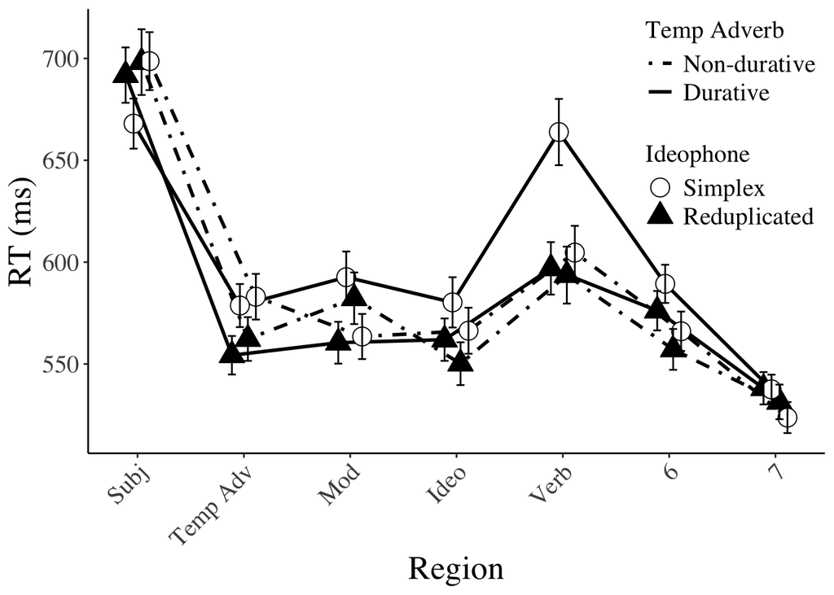

```r
#g <- g + theme_classic(base_size=20, base_family="HiraKakuProN-W3")
#g <- g + theme(base_size=20, base_family="Times", axis.text.x = element_text(angle = 45, hjust = 1))
g <- g + labs(x="Region", y="RT (ms)")
print(g)
```

```r
ggsave("Figure6_RawRT.png")
```

### 4.7.2 Interaction

Base

```r
rtg <- subset(rt_data_summary,region==criticalregion)
g <- ggplot(rtg,aes(x=A,y=mean,group=Conditions))
```

Add lines

```r
g <- g + geom_line(size=1,aes(group=B,linetype=B))
g <- g + scale_linetype_manual(values=c("dotdash","solid"))
g <- g + labs(linetype=Blabel)
```

Add points

```r
g <- g + geom_point(size=8,aes(shape=B,fill=B),position = position_dodge(.2))
g <- g + scale_shape_manual(values=c(21,24,24,25))
g <- g + scale_fill_manual(values=c("white","black","white","black"))
g <- g + labs(shape=Blabel)
g <- g + labs(fill=Blabel)
```

Add error bars

```r
g <- g + geom_errorbar(aes(ymin=mean-ci, ymax=mean+ci), width=.1,position = position_dodge(.2))
```

Adjust x-axis breaks

```r
#g <- g + scale_x_continuous(breaks=seq(1, 10, by=1))
```

Adjust appearance

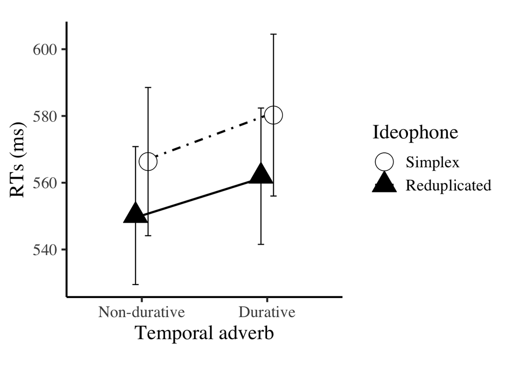

```r
g <- g + theme_classic(base_size=20, base_family="HiraKakuProN-W3")
g <- g + theme_classic(base_size=20, base_family="Times")
g <- g + theme(aspect.ratio = 1) #Ratio of y-bar to x-bar=1
g <- g + labs(x="Temporal adverb", y=RTlabel)
print(g)
```

```r
ggsave("Figure7_R4.png")
```

### 4.7.3 Interaction

Base

```r
rtg <- subset(rt_data_summary,region==criticalregion+1)
g <- ggplot(rtg,aes(x=A,y=mean,group=Conditions))
```

Add lines

```r
g <- g + geom_line(size=1,aes(group=B,linetype=B))
g <- g + scale_linetype_manual(values=c("dotdash","solid"))
g <- g + labs(linetype=Blabel)
```

Add points

```r
g <- g + geom_point(size=8,aes(shape=B,fill=B),position = position_dodge(.2))
g <- g + scale_shape_manual(values=c(21,24,24,25))
g <- g + scale_fill_manual(values=c("white","black","white","black"))
g <- g + labs(shape=Blabel)
g <- g + labs(fill=Blabel)
```

Add error bars

```r
g <- g + geom_errorbar(aes(ymin=mean-ci, ymax=mean+ci), width=.1,position = position_dodge(.2))
```

Adjust x-axis breaks

```r
#g <- g + scale_x_continuous(breaks=seq(1, 10, by=1))
```

Adjust appearance

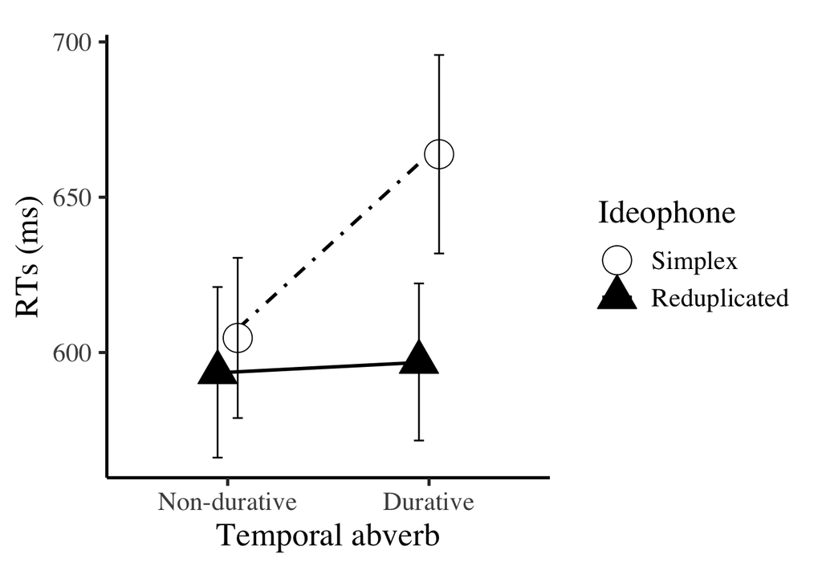

```r
g <- g + theme_classic(base_size=20, base_family="HiraKakuProN-W3")
g <- g + theme_classic(base_size=20, base_family="Times")
g <- g + theme(aspect.ratio = 1) #Ratio of y-bar to x-bar=1
g <- g + labs(x="Temporal abverb", y=RTlabel)
print(g)
```

```r
ggsave("Figure8_R5.png")
```

### 4.7.4 Interaction

Base

```r
rtg <- subset(rt_data_summary,region==criticalregion+2)
g <- ggplot(rtg,aes(x=A,y=mean,group=Conditions))
```

Add lines

```r
g <- g + geom_line(size=1,aes(group=B,linetype=B))
g <- g + scale_linetype_manual(values=c("dotdash","solid"))
g <- g + labs(linetype=Blabel)
```

Add points

```r
g <- g + geom_point(size=8,aes(shape=B,fill=B), position = position_dodge(.2))
g <- g + scale_shape_manual(values=c(21,24,24,25))
g <- g + scale_fill_manual(values=c("white","black","black","white"))
g <- g + labs(shape=Blabel)
g <- g + labs(fill=Blabel)
```

Add error bars

```r
g <- g + geom_errorbar(aes(ymin=mean-ci, ymax=mean+ci), width=.1, position = position_dodge(.2))
```

Adjust x-axis breaks

```r
#g <- g + scale_x_continuous(breaks=seq(1, 10, by=1))
```

Adjust appearance

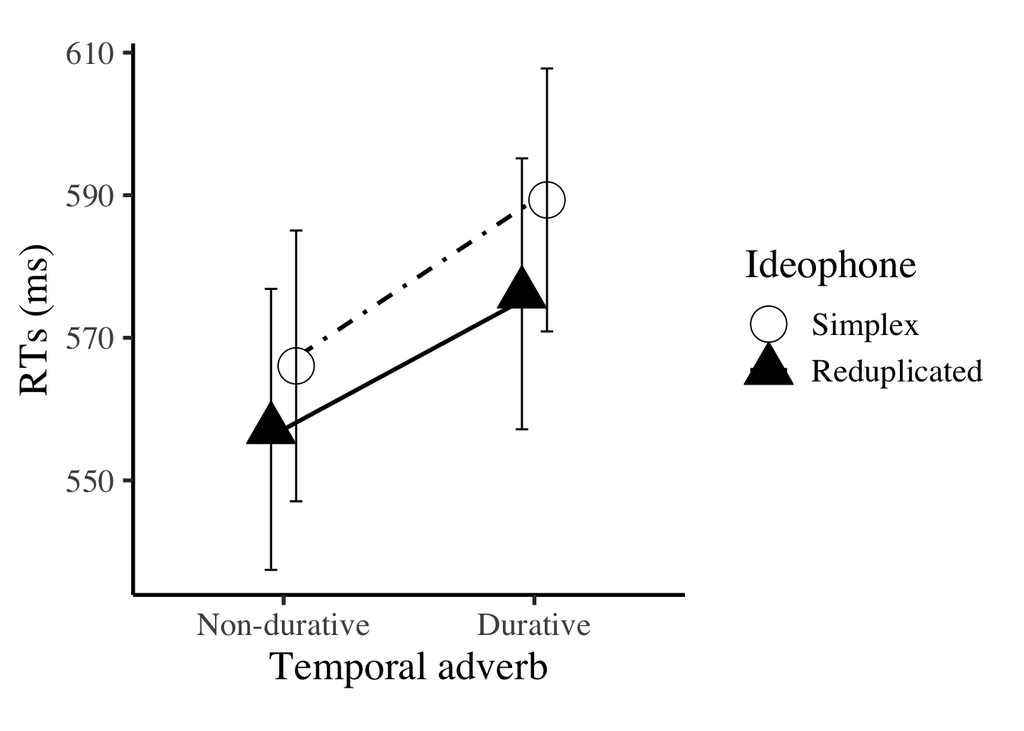

```r
g <- g + theme_classic(base_size=20, base_family="HiraKakuProN-W3")
g <- g + theme_classic(base_size=20, base_family="Times")
g <- g + theme(aspect.ratio = 1) #Ratio of y-bar to x-bar=1
g <- g + labs(x="Temporal adverb", y=RTlabel)
print(g)
```

```r
ggsave("Figure9_R6.png")
```

### 4.7.5 Plot the mean RTs against Itemvalue

```r
itemvaluedata <- subset(rt_data,region<=criticalregion+crplus)

itemvalue_data_summary <- ddply(itemvaluedata, .(Itemvalue,cond,region), summarise, N=length(rt), mean=mean(rt), sd=sd(rt), se=sd/sqrt(N),ci=qt(0.975,df=N-1)*se)
```

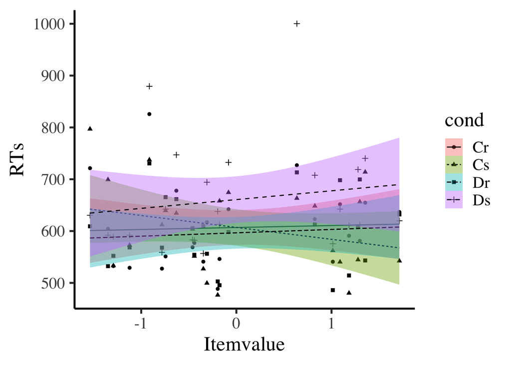

```r
cregion <- subset(itemvalue_data_summary,region==criticalregion+1)
g <- ggplot(cregion,aes(x=Itemvalue,y=mean,shape=cond,fill=cond,linetype=cond))
g <- g + geom_point()

# Manually specify the shapes, colors, linetypes
#g <- g + scale_shape_manual(values=c(25,22))
#g <- g + scale_fill_manual(values=c("grey","black"))
#g <- g + scale_linetype_manual(values=c("dashed","solid"))

# smoother
g <- g + geom_smooth(method="lm",colour="black",size=0.5)

# theme
g <- g + theme_classic(base_size=20, base_family="Times")

# labels
g <- g + xlab("Itemvalue")
g <- g + ylab("RTs")
g <- g + labs(type="Dependency type")

print(g)
```

### 4.7.6 Plot the mean RTs against Itemvalue: Nondurative only

```r
itemvaluedata <- subset(rt_data,region<=criticalregion+crplus)

itemvalue_data_summary <- ddply(itemvaluedata, .(Itemvalue,cond,region), summarise, N=length(rt), mean=mean(rt), sd=sd(rt), se=sd/sqrt(N),ci=qt(0.975,df=N-1)*se)
```

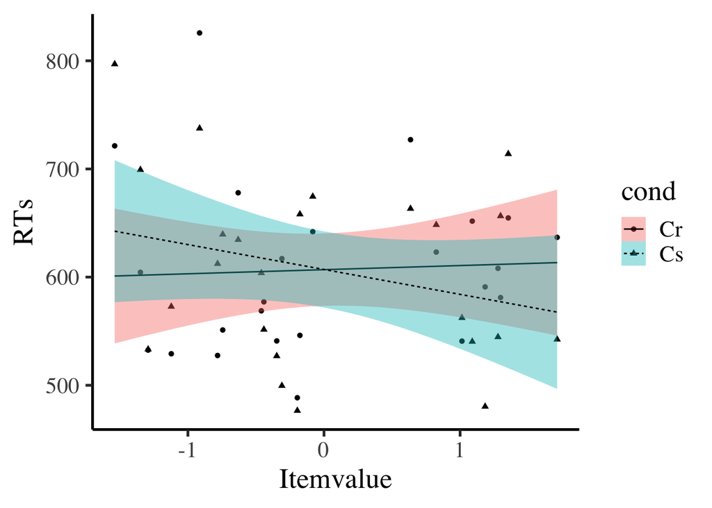

```r
cregion <- subset(itemvalue_data_summary,region==criticalregion+1)
cregion <- subset(cregion, cond=="Cr"|cond=="Cs")
g <- ggplot(cregion,aes(x=Itemvalue,y=mean,shape=cond,fill=cond,linetype=cond))
g <- g + geom_point()

# Manually specify the shapes, colors, linetypes
#g <- g + scale_shape_manual(values=c(25,22))
#g <- g + scale_fill_manual(values=c("grey","black"))
#g <- g + scale_linetype_manual(values=c("dashed","solid"))

# smoother
g <- g + geom_smooth(method="lm",colour="black",size=0.5)

# theme
g <- g + theme_classic(base_size=20, base_family="Times")

# labels
g <- g + xlab("Itemvalue")
g <- g + ylab("RTs")
g <- g + labs(type="Dependency type")

print(g)
```

# 5 Analyses

## 5.1 Coding factors

```r
rt_data$Adv<-ifelse(rt_data$cond%in%c("Dr","Ds"),1,-1)
rt_data$Ideo<-ifelse(rt_data$cond%in%c("Ds","Cs"),1,-1)
```

rt_data check

```r
dc <- subset(rt_data,cond=="Cr",c(cond,word,Adv,Ideo))
head(dc, n=7)
```

```
##   cond         word Adv Ideo
## 1   Cr       生徒が  -1   -1
## 2   Cr       その時  -1   -1
## 3   Cr       黒板を  -1   -1
## 4   Cr     ちらちら  -1   -1
## 5   Cr     見たので  -1   -1
## 6   Cr       先生が  -1   -1
## 7   Cr カンニングを  -1   -1
```

```r
dc <- subset(rt_data,cond=="Cs",c(cond,word,Adv,Ideo))
head(dc, n=7)
```

```
##    cond         word Adv Ideo
## 9    Cs       生徒が  -1    1
## 10   Cs       その時  -1    1
## 11   Cs       黒板を  -1    1
## 12   Cs     ちらっと  -1    1
## 13   Cs     見たので  -1    1
## 14   Cs       先生が  -1    1
## 15   Cs カンニングを  -1    1
```

```r
dc <- subset(rt_data,cond=="Dr",c(cond,word,Adv,Ideo))
head(dc, n=7)
```

```
##    cond         word Adv Ideo
## 33   Dr       生徒が   1   -1
## 34   Dr     しばらく   1   -1
## 35   Dr       黒板を   1   -1
## 36   Dr     ちらちら   1   -1
## 37   Dr     見たので   1   -1
## 38   Dr       先生が   1   -1
## 39   Dr カンニングを   1   -1
```

```r
dc <- subset(rt_data,cond=="Ds",c(cond,word,Adv,Ideo))
head(dc, n=7)
```

```
##    cond         word Adv Ideo
## 73   Ds       生徒が   1    1
## 74   Ds     しばらく   1    1
## 75   Ds       黒板を   1    1
## 76   Ds     ちらっと   1    1
## 77   Ds     見たので   1    1
## 78   Ds       先生が   1    1
## 79   Ds カンニングを   1    1
```

Make sure factors are treated as factors

```r
rt_data$subj<-factor(rt_data$subj)
rt_data$expt<-factor(rt_data$expt)
rt_data$item<-factor(rt_data$item)
rt_data$cond<-factor(rt_data$cond)
rt_data$word<-factor(rt_data$word)
```

## 5.2 Critical(Ideophone) region

```r
cregion<-subset(rt_data,region==criticalregion)
```

Check words

```r
sort(unique(cregion$word))
```

```
##  [1] カチャカチャ カチャッと   キュキュッと キュッと     ぐさぐさ
##  [6] ぐさっと     ぐらぐら     ぐらっと     クルクル     ぐるぐる
## [11] クルッと     ぐるっと     ごほごほ     ごほっと     サクサク
## [16] ざくざく     サクッと     ざくっと     ずきずき     ずきっと
## [21] ズルズル     ズルッと     ちらちら     ちらっと     ぱしゃっと
## [26] ぱしゃぱしゃ ぱちっと     ぱちぱち     ぱらっと     ぱらぱら
## [31] バンッと     バンバン     ぴかっと     ぴかぴか     ピョンと
## [36] ピョンピョン ぶんっと     ぶんぶん     ぺこっと     ぺこぺこ
## [41] ボキッと     ポキッと     ボキボキ     ポキポキ     ポロッと
## [46] ポロポロ
## 189 Levels: あがった。 あげた。 アルバイトが お辞儀したので ... 鼻を
```

Max model

```r
mm<-lmer(rt~Adv+Ideo+Adv:Ideo+
           (1+Adv+Ideo+Adv:Ideo|subj)+(1+Adv+Ideo+Adv:Ideo|item),
           control=lmerControl(optimizer="bobyqa"),
           cregion)
```

```
## boundary (singular) fit: see help('isSingular')
```

```r
summary(mm)
```

```
## Linear mixed model fit by REML. t-tests use Satterthwaite's method [
## lmerModLmerTest]
## Formula: rt ~ Adv + Ideo + Adv:Ideo + (1 + Adv + Ideo + Adv:Ideo | subj) +
##     (1 + Adv + Ideo + Adv:Ideo | item)
##    Data: cregion
## Control: lmerControl(optimizer = "bobyqa")
##
## REML criterion at convergence: 29502.9
##
## Scaled residuals:
##     Min      1Q  Median      3Q     Max
## -2.6937 -0.5049 -0.1718  0.2847  6.1278
##
## Random effects:
##  Groups   Name        Variance Std.Dev. Corr
##  subj     (Intercept) 32752.49 180.976
##           Adv           431.46  20.772  0.19
##           Ideo          309.27  17.586  0.64 0.74
##           Adv:Ideo      410.61  20.263  0.12 0.96 0.79
##  item     (Intercept)   968.58  31.122
##           Adv           167.94  12.959  0.64
##           Ideo           14.59   3.819  1.00 0.70
##           Adv:Ideo      164.22  12.815  0.41 0.96 0.48
##  Residual             34418.54 185.522
## Number of obs: 2191, groups:  subj, 110; item, 24
##
## Fixed effects:
##             Estimate Std. Error       df t value Pr(>|t|)
## (Intercept) 566.1888    18.8330 120.0962  30.064   <2e-16 ***
## Adv           5.6269     5.2240  37.7960   1.077    0.288
## Ideo          6.2894     4.4367 115.6298   1.418    0.159
## Adv:Ideo     -0.8627     5.1824  34.6346  -0.166    0.869
## ---
## Signif. codes:  0 '***' 0.001 '**' 0.01 '*' 0.05 '.' 0.1 ' ' 1
##
## Correlation of Fixed Effects:
##          (Intr) Adv   Ideo
## Adv      0.165
## Ideo     0.277  0.183
## Adv:Ideo 0.113  0.366 0.112
## optimizer (bobyqa) convergence code: 0 (OK)
## boundary (singular) fit: see help('isSingular')
```

```r
(step_res <- step(mm, reduce.fixed = F))
```

[output not shown]

```
## boundary (singular) fit: see help('isSingular')
## boundary (singular) fit: see help('isSingular')
## boundary (singular) fit: see help('isSingular')
## boundary (singular) fit: see help('isSingular')
```

```
## Backward reduced random-effect table:
##
##                                                Eliminated npar logLik   AIC
## <none>                                                      25 -14752 29553
## Adv:Ideo in (1 + Adv + Ideo + Adv:Ideo | item)          1   21 -14754 29549
## Ideo in (Adv + Ideo | item)                             2   18 -14754 29544
## Adv in (Adv | item)                                     3   16 -14756 29543
## Adv:Ideo in (1 + Adv + Ideo + Adv:Ideo | subj)          0   12 -14761 29546
## (1 | item)                                              0   15 -14770 29570
##                                                    LRT Df Pr(>Chisq)
## <none>
## Adv:Ideo in (1 + Adv + Ideo + Adv:Ideo | item)  4.4614  4    0.34715
## Ideo in (Adv + Ideo | item)                     0.9098  3    0.82307
## Adv in (Adv | item)                             3.1158  2    0.21057
## Adv:Ideo in (1 + Adv + Ideo + Adv:Ideo | subj) 11.0606  4    0.02589 *
## (1 | item)                                     28.1775  1  1.107e-07 ***
## ---
## Signif. codes:  0 '***' 0.001 '**' 0.01 '*' 0.05 '.' 0.1 ' ' 1
##
## Backward reduced fixed-effect table:
## Degrees of freedom method: Satterthwaite
##
##          Eliminated Sum Sq Mean Sq NumDF  DenDF F value Pr(>F)
## Adv:Ideo          0 931.55  931.55     1 181.63  0.0268 0.8701
##
## Model found:
## rt ~ Adv + Ideo + (1 + Adv + Ideo + Adv:Ideo | subj) + (1 | item) + Adv:Ideo
```

```r
final <- get_model(step_res)
summary(final)
```

```
## Linear mixed model fit by REML. t-tests use Satterthwaite's method [
## lmerModLmerTest]
## Formula: rt ~ Adv + Ideo + (1 + Adv + Ideo + Adv:Ideo | subj) + (1 | item) +
##     Adv:Ideo
##    Data: cregion
## Control: lmerControl(optimizer = "bobyqa")
##
## REML criterion at convergence: 29511.4
##
## Scaled residuals:
##     Min      1Q  Median      3Q     Max
## -2.7105 -0.5010 -0.1745  0.2735  6.3324
##
## Random effects:
##  Groups   Name        Variance Std.Dev. Corr
##  subj     (Intercept) 32768.7  181.02
##           Adv           449.9   21.21   0.20
##           Ideo          310.2   17.61   0.66 0.75
##           Adv:Ideo      414.3   20.35   0.13 0.97 0.79
##  item     (Intercept)  1016.5   31.88
##  Residual             34749.4  186.41
## Number of obs: 2191, groups:  subj, 110; item, 24
##
## Fixed effects:
##             Estimate Std. Error       df t value Pr(>|t|)
## (Intercept) 566.4360    18.8973 119.9461  29.974   <2e-16 ***
## Adv           5.6225     4.5349 135.0085   1.240    0.217
## Ideo          6.2636     4.3791 160.3522   1.430    0.155
## Adv:Ideo     -0.7326     4.4743 181.6332  -0.164    0.870
## ---
## Signif. codes:  0 '***' 0.001 '**' 0.01 '*' 0.05 '.' 0.1 ' ' 1
##
## Correlation of Fixed Effects:
##          (Intr) Adv   Ideo
## Adv      0.066
## Ideo     0.225  0.148
## Adv:Ideo 0.055  0.156 0.082
## optimizer (bobyqa) convergence code: 0 (OK)
## boundary (singular) fit: see help('isSingular')
```

```r
anova(final)
```

```
## Type III Analysis of Variance Table with Satterthwaite's method
##          Sum Sq Mean Sq NumDF  DenDF F value Pr(>F)
## Adv       53416   53416     1 135.01  1.5372 0.2172
## Ideo      71092   71092     1 160.35  2.0459 0.1546
## Adv:Ideo    932     932     1 181.63  0.0268 0.8701
```

## 5.3 Verb region

```r
cregion<-subset(rt_data,region==criticalregion+1)
```

Check words

```r
sort(unique(cregion$word))
```

```
##  [1] お辞儀したので   すすったので     まばたきしたので めくったので
##  [5] 光ったので       切ったので       刺したので       刻んだので
##  [9] 叩いたので       咳き込んだので   回したので       回ったので
## [13] 折ったので       拭いたので       振ったので       揺れたので
## [17] 撮ったので       流したので       混ぜたので       痛んだので
## [21] 発砲したので     見たので         飛び越えたので   鳴らしたので
## 189 Levels: あがった。 あげた。 アルバイトが お辞儀したので ... 鼻を
```

Max model

```r
mm<-lmer(rt~Adv+Ideo+Adv:Ideo+
           (1+Adv+Ideo+Adv:Ideo|subj)+(1+Adv+Ideo+Adv:Ideo|item),
           control=lmerControl(optimizer="bobyqa"),
           cregion)
```

```
## boundary (singular) fit: see help('isSingular')
```

```r
summary(mm)
```

```
## Linear mixed model fit by REML. t-tests use Satterthwaite's method [
## lmerModLmerTest]
## Formula: rt ~ Adv + Ideo + Adv:Ideo + (1 + Adv + Ideo + Adv:Ideo | subj) +
##     (1 + Adv + Ideo + Adv:Ideo | item)
##    Data: cregion
## Control: lmerControl(optimizer = "bobyqa")
##
## REML criterion at convergence: 30292
##
## Scaled residuals:
##     Min      1Q  Median      3Q     Max
## -2.9946 -0.5019 -0.1672  0.2298  5.9070
##
## Random effects:
##  Groups   Name        Variance Std.Dev. Corr
##  subj     (Intercept) 52358.0  228.82
##           Adv           729.9   27.02   0.63
##           Ideo          726.3   26.95   0.49  0.99
##           Adv:Ideo      890.9   29.85   0.79  0.97  0.92
##  item     (Intercept)  3702.7   60.85
##           Adv           346.9   18.63    0.27
##           Ideo          103.9   10.19    0.84 -0.05
##           Adv:Ideo      289.9   17.03    0.67  0.83  0.51
##  Residual             53563.6  231.44
## Number of obs: 2177, groups:  subj, 110; item, 24
##
## Fixed effects:
##             Estimate Std. Error      df t value Pr(>|t|)
## (Intercept)  619.665     25.632 114.646  24.176  < 2e-16 ***
## Adv           12.444      6.875  29.436   1.810  0.08052 .
## Ideo          17.655      6.042  48.692   2.922  0.00526 **
## Adv:Ideo      14.056      6.759  35.593   2.080  0.04482 *
## ---
## Signif. codes:  0 '***' 0.001 '**' 0.01 '*' 0.05 '.' 0.1 ' ' 1
##
## Correlation of Fixed Effects:
##          (Intr) Adv   Ideo
## Adv      0.260
## Ideo     0.312  0.163
## Adv:Ideo 0.455  0.376 0.222
## optimizer (bobyqa) convergence code: 0 (OK)
## boundary (singular) fit: see help('isSingular')
```

```r
(step_res <- step(mm, reduce.fixed = F))
```

[output not shown]

```
## Backward reduced random-effect table:
##
##                                                Eliminated npar logLik   AIC
## <none>                                                      25 -15146 30342
## Adv:Ideo in (1 + Adv + Ideo + Adv:Ideo | item)          1   21 -15149 30340
## Adv in (Adv + Ideo | item)                              2   18 -15151 30338
## Ideo in (Ideo | item)                                   3   16 -15152 30336
## Adv:Ideo in (1 + Adv + Ideo + Adv:Ideo | subj)          0   12 -15164 30352
## (1 | item)                                              0   15 -15196 30421
##                                                   LRT Df Pr(>Chisq)
## <none>
## Adv:Ideo in (1 + Adv + Ideo + Adv:Ideo | item)  6.206  4     0.1843
## Adv in (Adv + Ideo | item)                      3.363  3     0.3390
## Ideo in (Ideo | item)                           2.616  2     0.2704
## Adv:Ideo in (1 + Adv + Ideo + Adv:Ideo | subj) 23.657  4  9.355e-05 ***
## (1 | item)                                     86.908  1  < 2.2e-16 ***
## ---
## Signif. codes:  0 '***' 0.001 '**' 0.01 '*' 0.05 '.' 0.1 ' ' 1
##
## Backward reduced fixed-effect table:
## Degrees of freedom method: Satterthwaite
##
##          Eliminated Sum Sq Mean Sq NumDF  DenDF F value  Pr(>F)
## Adv:Ideo          0 358175  358175     1 155.28  6.5937 0.01118 *
## ---
## Signif. codes:  0 '***' 0.001 '**' 0.01 '*' 0.05 '.' 0.1 ' ' 1
##
## Model found:
## rt ~ Adv + Ideo + (1 + Adv + Ideo + Adv:Ideo | subj) + (1 | item) + Adv:Ideo
```

```r
final <- get_model(step_res)
summary(final)
```

```
## Linear mixed model fit by REML. t-tests use Satterthwaite's method [
## lmerModLmerTest]
## Formula: rt ~ Adv + Ideo + (1 + Adv + Ideo + Adv:Ideo | subj) + (1 | item) +
##     Adv:Ideo
##    Data: cregion
## Control: lmerControl(optimizer = "bobyqa")
##
## REML criterion at convergence: 30304.2
##
## Scaled residuals:
##    Min     1Q Median     3Q    Max
## -2.955 -0.500 -0.162  0.231  6.147
##
## Random effects:
##  Groups   Name        Variance Std.Dev. Corr
##  subj     (Intercept) 52305.4  228.70
##           Adv           712.1   26.69   0.63
##           Ideo          703.4   26.52   0.50 0.99
##           Adv:Ideo      911.7   30.20   0.79 0.98 0.93
##  item     (Intercept)  3663.5   60.53
##  Residual             54320.7  233.07
## Number of obs: 2177, groups:  subj, 110; item, 24
##
## Fixed effects:
##             Estimate Std. Error      df t value Pr(>|t|)
## (Intercept)  619.871     25.595 115.131  24.219  < 2e-16 ***
## Adv           12.856      5.706 153.503   2.253  0.02566 *
## Ideo          17.492      5.672 150.601   3.084  0.00243 **
## Adv:Ideo      14.943      5.819 155.283   2.568  0.01118 *
## ---
## Signif. codes:  0 '***' 0.001 '**' 0.01 '*' 0.05 '.' 0.1 ' ' 1
##
## Correlation of Fixed Effects:
##          (Intr) Adv   Ideo
## Adv      0.227
## Ideo     0.184  0.219
## Adv:Ideo 0.336  0.185 0.164
## optimizer (bobyqa) convergence code: 0 (OK)
## boundary (singular) fit: see help('isSingular')
```

```r
anova(final)
```

```
## Type III Analysis of Variance Table with Satterthwaite's method
##          Sum Sq Mean Sq NumDF  DenDF F value   Pr(>F)
## Adv      275775  275775     1 153.50  5.0768 0.025665 *
## Ideo     516543  516543     1 150.60  9.5091 0.002433 **
## Adv:Ideo 358175  358175     1 155.28  6.5937 0.011178 *
## ---
## Signif. codes:  0 '***' 0.001 '**' 0.01 '*' 0.05 '.' 0.1 ' ' 1
```

### 5.3.1 Conduct Pairwise Comparisons for the Interaction

Simple effect of Adv within each Ideo level

```r
# Pairwise comparisons
library(emmeans)
pairwise_results <- emmeans(final, pairwise ~ Adv | Ideo)
print(pairwise_results)
```

```
## $emmeans
## Ideo = -1:
##  Adv emmean   SE  df lower.CL upper.CL
##   -1    604 26.9 120      551      658
##    1    600 25.5 115      550      651
##
## Ideo =  1:
##  Adv emmean   SE  df lower.CL upper.CL
##   -1    610 25.1 114      560      659
##    1    665 31.8 125      602      728
##
## Degrees-of-freedom method: kenward-roger
## Confidence level used: 0.95
##
## $contrasts
## Ideo = -1:
##  contrast       estimate   SE  df t.ratio p.value
##  (Adv-1) - Adv1     4.17 14.7 109   0.283  0.7777
##
## Ideo =  1:
##  contrast       estimate   SE  df t.ratio p.value
##  (Adv-1) - Adv1   -55.60 17.8 108  -3.130  0.0022
##
## Degrees-of-freedom method: kenward-roger
```

Simple effect of Ideo within each Adv level

```r
# Pairwise comparisons
pairwise_results <- emmeans(final, pairwise ~ Ideo | Adv)
print(pairwise_results)
```

```
## $emmeans
## Adv = -1:
##  Ideo emmean   SE  df lower.CL upper.CL
##    -1    604 26.9 120      551      658
##     1    610 25.1 114      560      659
##
## Adv =  1:
##  Ideo emmean   SE  df lower.CL upper.CL
##    -1    600 25.5 115      550      651
##     1    665 31.8 125      602      728
##
## Degrees-of-freedom method: kenward-roger
## Confidence level used: 0.95
##
## $contrasts
## Adv = -1:
##  contrast         estimate   SE  df t.ratio p.value
##  (Ideo-1) - Ideo1     -5.1 14.9 106  -0.342  0.7328
##
## Adv =  1:
##  contrast         estimate   SE  df t.ratio p.value
##  (Ideo-1) - Ideo1    -64.9 17.5 108  -3.696  0.0003
##
## Degrees-of-freedom method: kenward-roger
```

### 5.3.2 Itemvalue

```r
mm<-lmer(rt~Adv+Ideo+Adv:Ideo+Adv:Itemvalue+Ideo:Itemvalue+Adv:Ideo:Itemvalue+Itemvalue+
           (1+Adv+Ideo+Adv:Ideo+Adv:Itemvalue+Ideo:Itemvalue+Adv:Ideo:Itemvalue+Itemvalue|subj),
           control=lmerControl(optimizer="bobyqa"),
           cregion)
```

```
## boundary (singular) fit: see help('isSingular')
```

```r
summary(mm)
```

```
## Linear mixed model fit by REML. t-tests use Satterthwaite's method [
## lmerModLmerTest]
## Formula: rt ~ Adv + Ideo + Adv:Ideo + Adv:Itemvalue + Ideo:Itemvalue +
##     Adv:Ideo:Itemvalue + Itemvalue + (1 + Adv + Ideo + Adv:Ideo +
##     Adv:Itemvalue + Ideo:Itemvalue + Adv:Ideo:Itemvalue + Itemvalue |
##     subj)
##    Data: cregion
## Control: lmerControl(optimizer = "bobyqa")
##
## REML criterion at convergence: 30322.9
##
## Scaled residuals:
##     Min      1Q  Median      3Q     Max
## -3.1220 -0.4934 -0.1739  0.2479  6.6691
##
## Random effects:
##  Groups   Name               Variance Std.Dev. Corr
##  subj     (Intercept)        53420.4  231.13
##           Adv                 1838.2   42.87    0.54
##           Ideo                 987.5   31.42    0.47  0.96
##           Itemvalue            390.3   19.76    0.34  0.06 -0.11
##           Adv:Ideo            1677.2   40.95    0.62  0.64  0.75 -0.44
##           Adv:Itemvalue       1837.2   42.86   -0.15 -0.84 -0.75  0.18 -0.39
##           Ideo:Itemvalue      1408.5   37.53    0.18  0.07  0.02  0.87 -0.35
##           Adv:Ideo:Itemvalue  1039.3   32.24    0.04 -0.77 -0.79  0.45 -0.49
##  Residual                    53110.5  230.46
##
##
##
##
##
##
##
##   0.28
##   0.92  0.38
##
## Number of obs: 2177, groups:  subj, 110
##
## Fixed effects:
##                    Estimate Std. Error      df t value Pr(>|t|)
```

[output cut: 8 more lines]

```
## ---
## Signif. codes:  0 '***' 0.001 '**' 0.01 '*' 0.05 '.' 0.1 ' ' 1
##
## Correlation of Fixed Effects:
##             (Intr) Adv    Ideo   Itemvl Adv:Id Adv:It Id:Itm
## Adv          0.320
## Ideo         0.237  0.334
## Itemvalue    0.099  0.015 -0.055
## Adv:Ideo     0.372  0.253  0.203 -0.087
## Adv:Itemval -0.085 -0.326 -0.213  0.027 -0.147
## Ideo:Itemvl  0.091  0.024 -0.026  0.161 -0.122  0.137
## Adv:Id:Itmv  0.017 -0.234 -0.170  0.156 -0.155  0.258  0.077
## optimizer (bobyqa) convergence code: 0 (OK)
## boundary (singular) fit: see help('isSingular')
## maxfun < 10 * length(par)^2 is not recommended.
```

```r
(step_res <- step(mm, reduce.fixed = F))
```

```
## boundary (singular) fit: see help('isSingular')
```

```
## Backward reduced random-effect table:
##
##                                                                                                                            Eliminated
## <none>
## Adv:Ideo:Itemvalue in (1 + Adv + Ideo + Adv:Ideo + Adv:Itemvalue + Ideo:Itemvalue + Adv:Ideo:Itemvalue + Itemvalue | subj)          0
##                                                                                                                            npar
## <none>                                                                                                                       45
## Adv:Ideo:Itemvalue in (1 + Adv + Ideo + Adv:Ideo + Adv:Itemvalue + Ideo:Itemvalue + Adv:Ideo:Itemvalue + Itemvalue | subj)   37
##                                                                                                                            logLik
## <none>                                                                                                                     -15162
## Adv:Ideo:Itemvalue in (1 + Adv + Ideo + Adv:Ideo + Adv:Itemvalue + Ideo:Itemvalue + Adv:Ideo:Itemvalue + Itemvalue | subj) -15172
##                                                                                                                              AIC
## <none>                                                                                                                     30413
## Adv:Ideo:Itemvalue in (1 + Adv + Ideo + Adv:Ideo + Adv:Itemvalue + Ideo:Itemvalue + Adv:Ideo:Itemvalue + Itemvalue | subj) 30417
##                                                                                                                              LRT
## <none>
## Adv:Ideo:Itemvalue in (1 + Adv + Ideo + Adv:Ideo + Adv:Itemvalue + Ideo:Itemvalue + Adv:Ideo:Itemvalue + Itemvalue | subj) 20.36
##                                                                                                                            Df
## <none>
## Adv:Ideo:Itemvalue in (1 + Adv + Ideo + Adv:Ideo + Adv:Itemvalue + Ideo:Itemvalue + Adv:Ideo:Itemvalue + Itemvalue | subj)  8
##                                                                                                                            Pr(>Chisq)
## <none>
## Adv:Ideo:Itemvalue in (1 + Adv + Ideo + Adv:Ideo + Adv:Itemvalue + Ideo:Itemvalue + Adv:Ideo:Itemvalue + Itemvalue | subj)   0.009057
##
## <none>
## Adv:Ideo:Itemvalue in (1 + Adv + Ideo + Adv:Ideo + Adv:Itemvalue + Ideo:Itemvalue + Adv:Ideo:Itemvalue + Itemvalue | subj) **
## ---
## Signif. codes:  0 '***' 0.001 '**' 0.01 '*' 0.05 '.' 0.1 ' ' 1
##
## Backward reduced fixed-effect table:
## Degrees of freedom method: Satterthwaite
##
##                    Eliminated Sum Sq Mean Sq NumDF  DenDF F value Pr(>F)
## Adv:Ideo:Itemvalue          0 5591.5  5591.5     1 188.09  0.1053 0.7459
##
## Model found:
## rt ~ Adv + Ideo + Adv:Ideo + Adv:Itemvalue + Ideo:Itemvalue + Adv:Ideo:Itemvalue + Itemvalue + (1 + Adv + Ideo + Adv:Ideo + Adv:Itemvalue + Ideo:Itemvalue + Adv:Ideo:Itemvalue + Itemvalue | subj)
```

```r
final <- get_model(step_res)
summary(final)
```

```
## Linear mixed model fit by REML. t-tests use Satterthwaite's method [
## lmerModLmerTest]
## Formula: rt ~ Adv + Ideo + Adv:Ideo + Adv:Itemvalue + Ideo:Itemvalue +
##     Adv:Ideo:Itemvalue + Itemvalue + (1 + Adv + Ideo + Adv:Ideo +
##     Adv:Itemvalue + Ideo:Itemvalue + Adv:Ideo:Itemvalue + Itemvalue |
##     subj)
##    Data: cregion
## Control: lmerControl(optimizer = "bobyqa")
##
## REML criterion at convergence: 30322.9
##
## Scaled residuals:
##     Min      1Q  Median      3Q     Max
## -3.1220 -0.4934 -0.1739  0.2479  6.6691
##
## Random effects:
##  Groups   Name               Variance Std.Dev. Corr
##  subj     (Intercept)        53420.4  231.13
##           Adv                 1838.2   42.87    0.54
##           Ideo                 987.5   31.42    0.47  0.96
##           Itemvalue            390.3   19.76    0.34  0.06 -0.11
##           Adv:Ideo            1677.2   40.95    0.62  0.64  0.75 -0.44
##           Adv:Itemvalue       1837.2   42.86   -0.15 -0.84 -0.75  0.18 -0.39
##           Ideo:Itemvalue      1408.5   37.53    0.18  0.07  0.02  0.87 -0.35
##           Adv:Ideo:Itemvalue  1039.3   32.24    0.04 -0.77 -0.79  0.45 -0.49
##  Residual                    53110.5  230.46
##
##
##
##
##
##
##
##   0.28
##   0.92  0.38
##
## Number of obs: 2177, groups:  subj, 110
##
## Fixed effects:
##                    Estimate Std. Error      df t value Pr(>|t|)
```

[output cut: 8 more lines]

```
## ---
## Signif. codes:  0 '***' 0.001 '**' 0.01 '*' 0.05 '.' 0.1 ' ' 1
##
## Correlation of Fixed Effects:
##             (Intr) Adv    Ideo   Itemvl Adv:Id Adv:It Id:Itm
## Adv          0.320
## Ideo         0.237  0.334
## Itemvalue    0.099  0.015 -0.055
## Adv:Ideo     0.372  0.253  0.203 -0.087
## Adv:Itemval -0.085 -0.326 -0.213  0.027 -0.147
## Ideo:Itemvl  0.091  0.024 -0.026  0.161 -0.122  0.137
## Adv:Id:Itmv  0.017 -0.234 -0.170  0.156 -0.155  0.258  0.077
## optimizer (bobyqa) convergence code: 0 (OK)
## boundary (singular) fit: see help('isSingular')
## maxfun < 10 * length(par)^2 is not recommended.
```

```r
anova(final)
```

```
## Type III Analysis of Variance Table with Satterthwaite's method
##                    Sum Sq Mean Sq NumDF   DenDF F value    Pr(>F)
## Adv                411713  411713     1 105.859  7.7520 0.0063568 **
## Ideo               738947  738947     1 158.317 13.9134 0.0002663 ***
## Itemvalue           18047   18047     1 194.050  0.3398 0.5606204
## Adv:Ideo           314342  314342     1 108.400  5.9186 0.0166176 *
## Adv:Itemvalue       40364   40364     1 105.673  0.7600 0.3853044
## Ideo:Itemvalue      48175   48175     1  94.884  0.9071 0.3433124
## Adv:Ideo:Itemvalue   5592    5592     1 188.094  0.1053 0.7459423
## ---
## Signif. codes:  0 '***' 0.001 '**' 0.01 '*' 0.05 '.' 0.1 ' ' 1
```

#### 5.3.2.1 Ideo x itemvalue in non-durative

```r
# For pairwise comparisons
cregion$simplexVSredup_dur <-ifelse(cregion$Adv==1,
                          ifelse(cregion$Ideo==1,1,-1),
                          0)
cregion$simplexVSredup_nondur <-ifelse(cregion$Adv==-1,
                          ifelse(cregion$Ideo==1,1,-1),
                          0)
cregion$durVSnondur_simplex <-ifelse(cregion$Ideo==1,
                          ifelse(cregion$Adv==1,1,-1),
                          0)
cregion$durVSnondur_redup <-ifelse(cregion$Ideo==-1,
                          ifelse(cregion$Adv==1,1,-1),
                          0)
```

```r
mm<-lmer(rt~simplexVSredup_dur:Itemvalue+simplexVSredup_nondur:Itemvalue+Adv+Ideo+Itemvalue+Adv:Itemvalue+Adv:Ideo+
           (1+Adv*Ideo*Itemvalue|subj),
           control=lmerControl(optimizer="bobyqa"),
           cregion)
```

```
## boundary (singular) fit: see help('isSingular')
```

```r
summary(mm)
```

```
## Linear mixed model fit by REML. t-tests use Satterthwaite's method [
## lmerModLmerTest]
## Formula: rt ~ simplexVSredup_dur:Itemvalue + simplexVSredup_nondur:Itemvalue +
##     Adv + Ideo + Itemvalue + Adv:Itemvalue + Adv:Ideo + (1 +
##     Adv * Ideo * Itemvalue | subj)
##    Data: cregion
## Control: lmerControl(optimizer = "bobyqa")
##
## REML criterion at convergence: 30321.5
##
## Scaled residuals:
##     Min      1Q  Median      3Q     Max
## -3.1220 -0.4934 -0.1739  0.2479  6.6691
##
## Random effects:
##  Groups   Name               Variance Std.Dev. Corr
##  subj     (Intercept)        53420.4  231.13
##           Adv                 1838.2   42.87    0.54
##           Ideo                 987.5   31.42    0.47  0.96
##           Itemvalue            390.3   19.76    0.34  0.06 -0.11
##           Adv:Ideo            1677.2   40.95    0.62  0.64  0.75 -0.44
##           Adv:Itemvalue       1837.2   42.86   -0.15 -0.84 -0.75  0.18 -0.39
##           Ideo:Itemvalue      1408.5   37.53    0.18  0.07  0.02  0.87 -0.35
##           Adv:Ideo:Itemvalue  1039.3   32.24    0.04 -0.77 -0.79  0.45 -0.49
##  Residual                    53110.5  230.46
##
##
##
##
##
##
##
##   0.28
##   0.92  0.38
##
## Number of obs: 2177, groups:  subj, 110
##
## Fixed effects:
##                                 Estimate Std. Error      df t value Pr(>|t|)
## (Intercept)                      625.856     22.659 107.847  27.621  < 2e-16
```

[output cut: 16 more lines]

```
## ---
## Signif. codes:  0 '***' 0.001 '**' 0.01 '*' 0.05 '.' 0.1 ' ' 1
##
## Correlation of Fixed Effects:
##             (Intr) Adv    Ideo   Itemvl sVS_:I It:VS_ Itmv:A
## Adv          0.320
## Ideo         0.237  0.334
## Itemvalue    0.099  0.015 -0.055
## smplxVSr_:I  0.074 -0.142 -0.133  0.215
## Itmvl:smVS_  0.055  0.189  0.105  0.005  0.011
## Itemval:Adv -0.085 -0.326 -0.213  0.027  0.269 -0.087
## Adv:Ideo     0.372  0.253  0.203 -0.087 -0.189  0.024 -0.147
## optimizer (bobyqa) convergence code: 0 (OK)
## boundary (singular) fit: see help('isSingular')
## maxfun < 10 * length(par)^2 is not recommended.
```

```r
(step_res <- step(mm, reduce.fixed = F))
```

```
## boundary (singular) fit: see help('isSingular')
```

```
## Backward reduced random-effect table:
##
##                                                           Eliminated npar
## <none>                                                                 45
## Adv:Ideo:Itemvalue in (1 + Adv * Ideo * Itemvalue | subj)          0   37
##                                                           logLik   AIC   LRT Df
## <none>                                                    -15161 30412
## Adv:Ideo:Itemvalue in (1 + Adv * Ideo * Itemvalue | subj) -15171 30416 20.36  8
##                                                           Pr(>Chisq)
## <none>
## Adv:Ideo:Itemvalue in (1 + Adv * Ideo * Itemvalue | subj)   0.009057 **
## ---
## Signif. codes:  0 '***' 0.001 '**' 0.01 '*' 0.05 '.' 0.1 ' ' 1
##
## Backward reduced fixed-effect table:
## Degrees of freedom method: Satterthwaite
##
##                                 Eliminated Sum Sq Mean Sq NumDF  DenDF F value
## simplexVSredup_dur:Itemvalue             0   9930    9930     1 125.44  0.1870
## Itemvalue:simplexVSredup_nondur          0  47164   47164     1 155.53  0.8880
## Itemvalue:Adv                            0  40364   40364     1 105.67  0.7600
## Adv:Ideo                                 0 314342  314342     1 108.40  5.9186
##                                  Pr(>F)
## simplexVSredup_dur:Itemvalue    0.66620
## Itemvalue:simplexVSredup_nondur 0.34747
## Itemvalue:Adv                   0.38530
## Adv:Ideo                        0.01662 *
## ---
## Signif. codes:  0 '***' 0.001 '**' 0.01 '*' 0.05 '.' 0.1 ' ' 1
##
## Model found:
## rt ~ simplexVSredup_dur:Itemvalue + simplexVSredup_nondur:Itemvalue + Adv + Ideo + Itemvalue + Adv:Itemvalue + Adv:Ideo + (1 + Adv * Ideo * Itemvalue | subj)
```

```r
final <- get_model(step_res)
summary(final)
```

```
## Linear mixed model fit by REML. t-tests use Satterthwaite's method [
## lmerModLmerTest]
## Formula: rt ~ simplexVSredup_dur:Itemvalue + simplexVSredup_nondur:Itemvalue +
##     Adv + Ideo + Itemvalue + Adv:Itemvalue + Adv:Ideo + (1 +
##     Adv * Ideo * Itemvalue | subj)
##    Data: cregion
## Control: lmerControl(optimizer = "bobyqa")
##
## REML criterion at convergence: 30321.5
##
## Scaled residuals:
##     Min      1Q  Median      3Q     Max
## -3.1220 -0.4934 -0.1739  0.2479  6.6691
##
## Random effects:
##  Groups   Name               Variance Std.Dev. Corr
##  subj     (Intercept)        53420.4  231.13
##           Adv                 1838.2   42.87    0.54
##           Ideo                 987.5   31.42    0.47  0.96
##           Itemvalue            390.3   19.76    0.34  0.06 -0.11
##           Adv:Ideo            1677.2   40.95    0.62  0.64  0.75 -0.44
##           Adv:Itemvalue       1837.2   42.86   -0.15 -0.84 -0.75  0.18 -0.39
##           Ideo:Itemvalue      1408.5   37.53    0.18  0.07  0.02  0.87 -0.35
##           Adv:Ideo:Itemvalue  1039.3   32.24    0.04 -0.77 -0.79  0.45 -0.49
##  Residual                    53110.5  230.46
##
##
##
##
##
##
##
##   0.28
##   0.92  0.38
##
## Number of obs: 2177, groups:  subj, 110
##
## Fixed effects:
##                                 Estimate Std. Error      df t value Pr(>|t|)
## (Intercept)                      625.856     22.659 107.847  27.621  < 2e-16
```

[output cut: 16 more lines]

```
## ---
## Signif. codes:  0 '***' 0.001 '**' 0.01 '*' 0.05 '.' 0.1 ' ' 1
##
## Correlation of Fixed Effects:
##             (Intr) Adv    Ideo   Itemvl sVS_:I It:VS_ Itmv:A
## Adv          0.320
## Ideo         0.237  0.334
## Itemvalue    0.099  0.015 -0.055
## smplxVSr_:I  0.074 -0.142 -0.133  0.215
## Itmvl:smVS_  0.055  0.189  0.105  0.005  0.011
## Itemval:Adv -0.085 -0.326 -0.213  0.027  0.269 -0.087
## Adv:Ideo     0.372  0.253  0.203 -0.087 -0.189  0.024 -0.147
## optimizer (bobyqa) convergence code: 0 (OK)
## boundary (singular) fit: see help('isSingular')
## maxfun < 10 * length(par)^2 is not recommended.
```

```r
anova(final)
```

```
## Type III Analysis of Variance Table with Satterthwaite's method
##                                 Sum Sq Mean Sq NumDF  DenDF F value    Pr(>F)
## Adv                             411713  411713     1 105.85  7.7520 0.0063569
## Ideo                            738947  738947     1 158.32 13.9134 0.0002663
## Itemvalue                        18047   18047     1 194.02  0.3398 0.5606212
## simplexVSredup_dur:Itemvalue      9930    9930     1 125.44  0.1870 0.6661987
## Itemvalue:simplexVSredup_nondur  47164   47164     1 155.53  0.8880 0.3474699
## Itemvalue:Adv                    40364   40364     1 105.67  0.7600 0.3853031
## Adv:Ideo                        314342  314342     1 108.40  5.9186 0.0166177
##
## Adv                             **
## Ideo                            ***
## Itemvalue
## simplexVSredup_dur:Itemvalue
## Itemvalue:simplexVSredup_nondur
## Itemvalue:Adv
## Adv:Ideo                        *
## ---
## Signif. codes:  0 '***' 0.001 '**' 0.01 '*' 0.05 '.' 0.1 ' ' 1
```

## 5.4 Spillover region

```r
cregion<-subset(rt_data,region==criticalregion+2)
```

Check words

```r
sort(unique(cregion$word))
```

```
##  [1] ケーキが         コーチが         すぐに           プロデューサーが
##  [5] 一瞬で           主任が           会場で           先生が
##  [9] 全員が           午前中に         台所が           子供が
## [13] 対戦相手が       店長が           母親が           激しく
## [17] 目が             看護師が         社員は           祖母は
## [21] 紙が             警察に           通行人は         風紀委員が
## 189 Levels: あがった。 あげた。 アルバイトが お辞儀したので ... 鼻を
```

## 5.5 Max model

```r
mm<-lmer(rt~Adv+Ideo+Adv:Ideo+
           (1+Adv+Ideo+Adv:Ideo|subj)+(1+Adv+Ideo+Adv:Ideo|item),
           control=lmerControl(optimizer="bobyqa"),
           cregion)
```

```
## boundary (singular) fit: see help('isSingular')
```

```r
summary(mm)
```

```
## Linear mixed model fit by REML. t-tests use Satterthwaite's method [
## lmerModLmerTest]
## Formula: rt ~ Adv + Ideo + Adv:Ideo + (1 + Adv + Ideo + Adv:Ideo | subj) +
##     (1 + Adv + Ideo + Adv:Ideo | item)
##    Data: cregion
## Control: lmerControl(optimizer = "bobyqa")
##
## REML criterion at convergence: 28670.2
##
## Scaled residuals:
##     Min      1Q  Median      3Q     Max
## -4.4555 -0.5561 -0.1615  0.3139  5.5074
##
## Random effects:
##  Groups   Name        Variance Std.Dev. Corr
##  subj     (Intercept) 25235.83 158.858
##           Adv            26.46   5.144  -1.00
##           Ideo          238.73  15.451   0.21 -0.21
##           Adv:Ideo      106.15  10.303  -0.29  0.29  0.87
##  item     (Intercept)  2007.77  44.808
##           Adv            44.97   6.706  -0.03
##           Ideo           38.50   6.205  -0.98 -0.17
##           Adv:Ideo      154.30  12.422   0.81 -0.61 -0.68
##  Residual             24095.21 155.226
## Number of obs: 2187, groups:  subj, 110; item, 24
##
## Fixed effects:
##             Estimate Std. Error      df t value Pr(>|t|)
## (Intercept)  571.430     18.029 113.216  31.695  < 2e-16 ***
## Adv           11.318      3.717  42.324   3.045  0.00399 **
## Ideo           5.228      3.920  70.443   1.334  0.18660
## Adv:Ideo      -2.013      4.345  30.323  -0.463  0.64646
## ---
## Signif. codes:  0 '***' 0.001 '**' 0.01 '*' 0.05 '.' 0.1 ' ' 1
##
## Correlation of Fixed Effects:
##          (Intr) Adv    Ideo
## Adv      -0.131
## Ideo     -0.105  0.004
## Adv:Ideo  0.190 -0.168 -0.101
## optimizer (bobyqa) convergence code: 0 (OK)
## boundary (singular) fit: see help('isSingular')
```

```r
(step_res <- step(mm, reduce.fixed = F))
```

```
## boundary (singular) fit: see help('isSingular')
## boundary (singular) fit: see help('isSingular')
```

```
## boundary (singular) fit: see help('isSingular')
## boundary (singular) fit: see help('isSingular')
```

[output not shown]

```
## Backward reduced random-effect table:
##
##                                                Eliminated npar logLik   AIC
## <none>                                                      25 -14335 28720
## Adv:Ideo in (1 + Adv + Ideo + Adv:Ideo | subj)          1   21 -14337 28715
## Ideo in (Adv + Ideo | subj)                             2   18 -14338 28711
## Adv in (Adv | subj)                                     3   16 -14338 28709
## Adv:Ideo in (1 + Adv + Ideo + Adv:Ideo | item)          0   12 -14343 28710
## (1 | subj)                                              0   15 -14927 29884
##                                                    LRT Df Pr(>Chisq)
## <none>
## Adv:Ideo in (1 + Adv + Ideo + Adv:Ideo | subj)    3.01  4    0.55667
## Ideo in (Adv + Ideo | subj)                       1.69  3    0.64006
## Adv in (Adv | subj)                               2.14  2    0.34280
## Adv:Ideo in (1 + Adv + Ideo + Adv:Ideo | item)    8.82  4    0.06584 .
## (1 | subj)                                     1176.62  1    < 2e-16 ***
## ---
## Signif. codes:  0 '***' 0.001 '**' 0.01 '*' 0.05 '.' 0.1 ' ' 1
##
## Backward reduced fixed-effect table:
## Degrees of freedom method: Satterthwaite
##
##          Eliminated Sum Sq Mean Sq NumDF  DenDF F value Pr(>F)
## Adv:Ideo          0 5745.9  5745.9     1 29.543  0.2346 0.6317
##
## Model found:
## rt ~ Adv + Ideo + (1 + Adv + Ideo + Adv:Ideo | item) + (1 | subj) + Adv:Ideo
```

```r
final <- get_model(step_res)
summary(final)
```

```
## Linear mixed model fit by REML. t-tests use Satterthwaite's method [
## lmerModLmerTest]
## Formula: rt ~ Adv + Ideo + (1 + Adv + Ideo + Adv:Ideo | item) + (1 | subj) +
##     Adv:Ideo
##    Data: cregion
## Control: lmerControl(optimizer = "bobyqa")
##
## REML criterion at convergence: 28677.1
##
## Scaled residuals:
##     Min      1Q  Median      3Q     Max
## -4.5399 -0.5566 -0.1584  0.3111  5.5596
##
## Random effects:
##  Groups   Name        Variance Std.Dev. Corr
##  subj     (Intercept) 25239.44 158.869
##  item     (Intercept)  2009.14  44.823
##           Adv            43.37   6.585  -0.02
##           Ideo           38.98   6.244  -0.99 -0.15
##           Adv:Ideo      147.93  12.163   0.82 -0.59 -0.71
##  Residual             24494.65 156.508
## Number of obs: 2187, groups:  subj, 110; item, 24
##
## Fixed effects:
##             Estimate Std. Error      df t value Pr(>|t|)
## (Intercept)  571.430     18.037 113.084  31.682  < 2e-16 ***
## Adv           11.344      3.698  41.501   3.068  0.00379 **
## Ideo           5.110      3.657  83.966   1.397  0.16600
## Adv:Ideo      -2.044      4.220  29.543  -0.484  0.63172
## ---
## Signif. codes:  0 '***' 0.001 '**' 0.01 '*' 0.05 '.' 0.1 ' ' 1
##
## Correlation of Fixed Effects:
##          (Intr) Adv    Ideo
## Adv      -0.019
## Ideo     -0.186  0.019
## Adv:Ideo  0.252 -0.173 -0.199
## optimizer (bobyqa) convergence code: 0 (OK)
## boundary (singular) fit: see help('isSingular')
```

```r
anova(final)
```

```
## Type III Analysis of Variance Table with Satterthwaite's method
##          Sum Sq Mean Sq NumDF  DenDF F value   Pr(>F)
## Adv      230521  230521     1 41.501  9.4111 0.003789 **
## Ideo      47826   47826     1 83.966  1.9525 0.165997
## Adv:Ideo   5746    5746     1 29.543  0.2346 0.631722
## ---
## Signif. codes:  0 '***' 0.001 '**' 0.01 '*' 0.05 '.' 0.1 ' ' 1
```